# Task 5 Trencin

Author

Viktor Molodov

Published

December 8, 2025

## Task 5. Visualising Your Universe (Base R & ggplot2)

You have found your data (Task 3) and built tools to analyse it (Task 4). Now, you must present your findings to customers.

Your goal is to create four specific visualizations based on the real-world dataset you imported in Task 3.

**Prerequisites:**

- Use the dataset you found and cleaned in Task 3.
- Make sure `library(ggplot2)` is loaded.
- **Crucial:** Every plot must have a **Title**, **x-axis label**, and **y-axis label** that make sense for your specific theme.

```r
library(readr)
library(dplyr)
library(ggplot2)
trencin_data <- read_csv("trencin_data.csv", show_col_types = FALSE)
```

### 5.1. The Quick Sketch (Base R Histogram)

Sometimes you need a quick look at the distribution of your data without loading heavy packages.

1. Choose one **numeric variable** from your dataset (e.g., `price`, `temperature`, `speed`).
2. Use the `hist()` function from base R.
3. Customise the `main` title, `xlab`, and the bar `col` (colour).

**Example:**

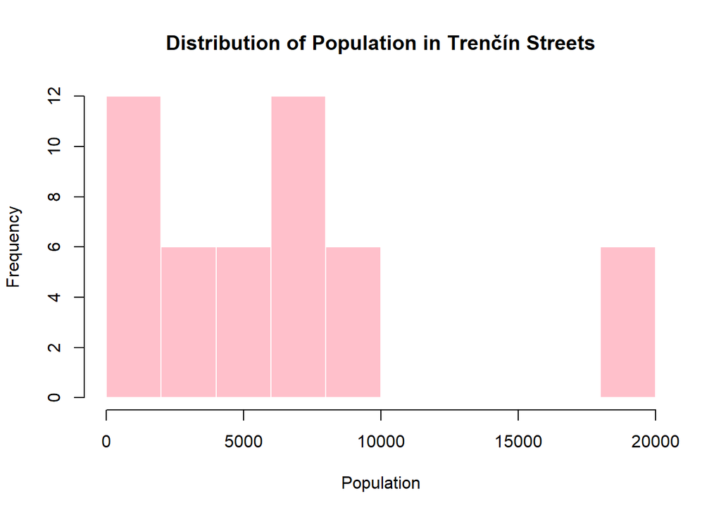

```r
hist(trencin_data$population,
main = "Distribution of Population in Trenčín Streets",
xlab = "Population",
col = "pink",
border = "white")
```

### 5.2. The Relationship Map (ggplot2 Scatter Plot)

Now, let’s look for patterns using the industry-standard package, **ggplot2**.

1. Choose **two numeric variables** to see if they are correlated.
2. Create a scatter plot using `geom_point()`.
3. Add `geom_smooth()` to add a relationship between variables to the plot.
4. Add `labs()` to rename your axes and title.

**Example:**

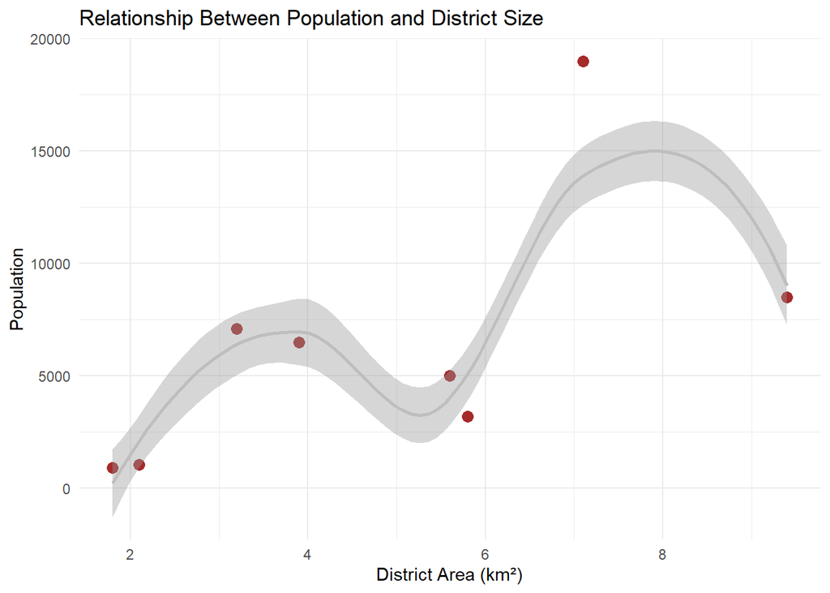

```r
ggplot(trencin_data, aes(x = district_sq_km, y = population)) +
geom_point(color = "brown", alpha = 0.7, size = 3) +
geom_smooth(color = "gray") +
labs(
title = "Relationship Between Population and District Size",
x = "District Area (km²)",
y = "Population"
) +
theme_minimal()
```

### 5.3. The Comparison (ggplot2 Boxplot)

3. The Comparison (ggplot2 Boxplot)

Boxplots are excellent for comparing groups. Let’s see how different categories in your universe perform.

1. Choose a **categorical (or logical) variable** for the X-axis (e.g., city, planet_type, species).
2. Choose a **numeric variable** for the Y-axis (e.g., price, gravity, lifespan).
3. Create a plot using `geom_boxplot()`.
4. **Bonus:** Use `fill` to colour the boxes by the same category.

**Example:**

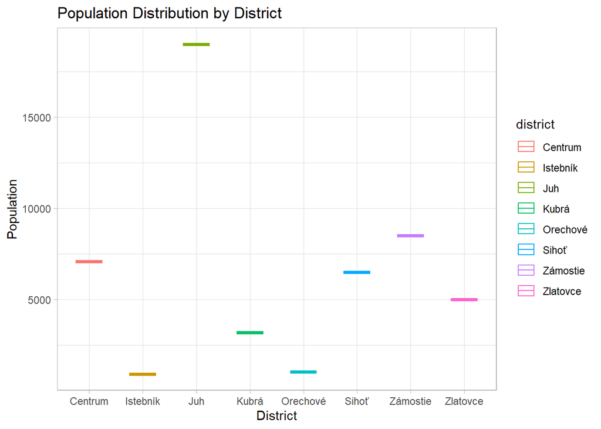

```r
ggplot(trencin_data, aes(x = district, y = population, color = district)) +
  stat_summary(fun = median, geom = "crossbar", width = 0.5) +
  labs(
    title = "Population Distribution by District",
    x = "District",
    y = "Population"
  ) +
  theme_light()
```

### 5.4. The “Deep Dive” (Faceting or Custom)

The most powerful feature of `ggplot2` is faceting—creating small multiples of the same plot for different groups.

1. Create a plot (histogram, bar plot, or scatter plot).
2. Use `facet_wrap(~ your_category_variable)` to split the plot into a separate panel for each group in your data.
3. This is incredibly useful for comparing distinct groups (e.g., separate charts for each City or Year).

**Example:**

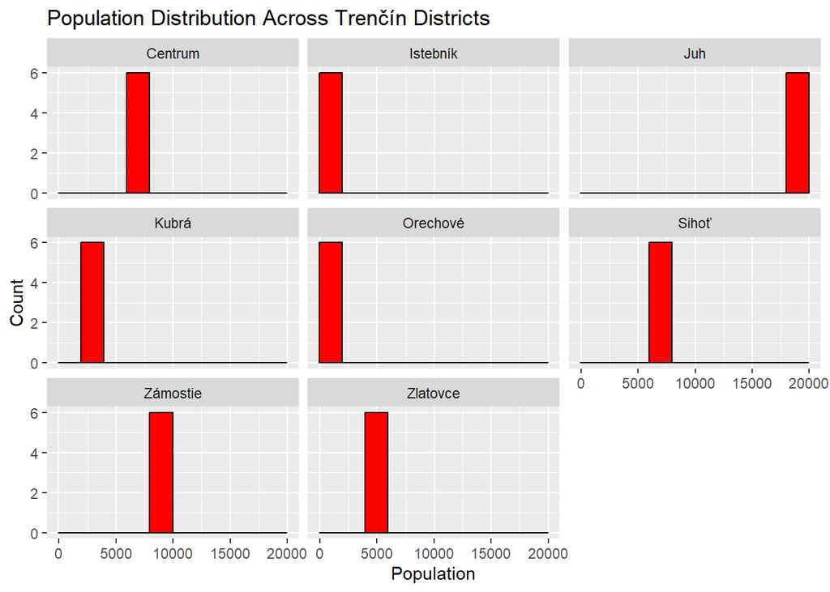

```r
ggplot(trencin_data, aes(x = population)) +
geom_histogram(bins = 10, fill = "red", color = "black") +
facet_wrap(~ district) +
labs(
title = "Population Distribution Across Trenčín Districts",
x = "Population",
y = "Count"
)
```

### 5.5. Final Step: Exporting (Saving Your Work)

A plot is useless if you can’t put it in a report.

1. Choose your favourite plot from the exercises above.
2. Run the code to display it in R.
3. Immediately run the following command to save it to your project folder:

```r
ggplot(trencin_data, aes(x = district_sq_km, y = population)) +
geom_point(color = "blue", alpha = 0.7, size = 3) +
geom_smooth(color = "gray") +
labs(
title = "Saved Plot — Population vs District Size",
x = "District Area (km²)",
y = "Population"
) +
theme_minimal()

ggsave("trencin_population_vs_area.png", width = 8, height = 6)
```